# Final Project: Willow

Merrimack College DSE6630: Healthcare & Life Sciences Analytics

Adeline Casali, Samantha Harper, Scott Eugley

26 June 2024

# Background and Hypothesis

The impact of environmental abiotic factors on gene expression is not well understood. Specifically, plants are immobile and must weather a wide variety of these abiotic stresses, which negatively impact plant growth. Plants can respond to these stresses by adjusting gene transcription and protein activity; however, stressors have been shown to have different effects on plants when combined (Ambroise et al., 2024).  
Ambroise et al. performed a controlled study on the impact of heavy metal and cold on *Salix viminalis* (Willow Tree) gene expression. The study produced count values which were used to identify differentially expressed genes (DEGs). In this paper, our aim was to examine the counts using a new DESeq2 and Random Forest model to identify DEGs.  
We hypothesize that willow trees that are exposed to more abiotic stressors such as cold or metal exposure will express different genes compared to normal conditions, because plants will often respond to cold by altering expression of genes involved in cold acclimatization and metals typically trigger genes associated with metal detoxification.

# Data Source

The *Salix viminalis* data was collected by Ambroise et al. during their investigation into the DEGs caused by heavy metal and cold exposure; their goal was to study the interaction between cold acclimation and heavy metals. They used four sample groups: control soil temperate (CT), control soil cold acclimated (CC), metal-polluted soil temperate (MT), and metal-polluted soil cold acclimated (MC). Plants were exposed to metals for two months before being exposed to cold for one month (Amroise et. al, 2024).  
The original analysis done by Ambroise et al. was performed using the edgeR package. Our analysis was performed using DESeq2 using the total contig. reads of each gene for each of the 12 samples.

# Results and Analysis

### Data Preprocessing

We began by loading the processed data and gene annotation files. The dataset comprised of total reads for each gene across 12 samples categorized into four treatment groups: control soil temperate (CT), control soil cold-acclimated (CC), metal-polluted soil temperate (MT), and metal-polluted soil cold-acclimated (MC). Metadata was also incorporated to provide contextual information for each sample. Column names were standardized to avoid potential errors in downstream analysis, and the data was converted to an appropriate format for DESeq analysis.  
Next, we created a DESeqDataSet object using the gene count data and metadata. The DESeqDataSet serves as a container for storing gene expression data along with experimental information, facilitating the application of DESeq2’s statistical methods. Additionally, to address the inherent variability in RNA-seq data, we applied a Variance Stabilizing Transformation (VST). This method normalizes the data by transforming count data and is particularly useful for reducing heteroscedasticity, making the data more amenable to analysis using linear models. The effectiveness of the VST was evaluated by plotting the mean-variance relationship before and after transformation (Figure 1). Post-transformation, the data exhibited a more linear relationship, indicating successful stabilization of variance.

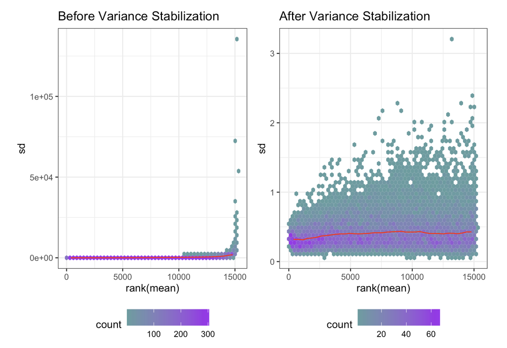

*Figure 1: Effects of the Variance Stabilizing Transformation on the data*

### Differential Gene Expression Analysis

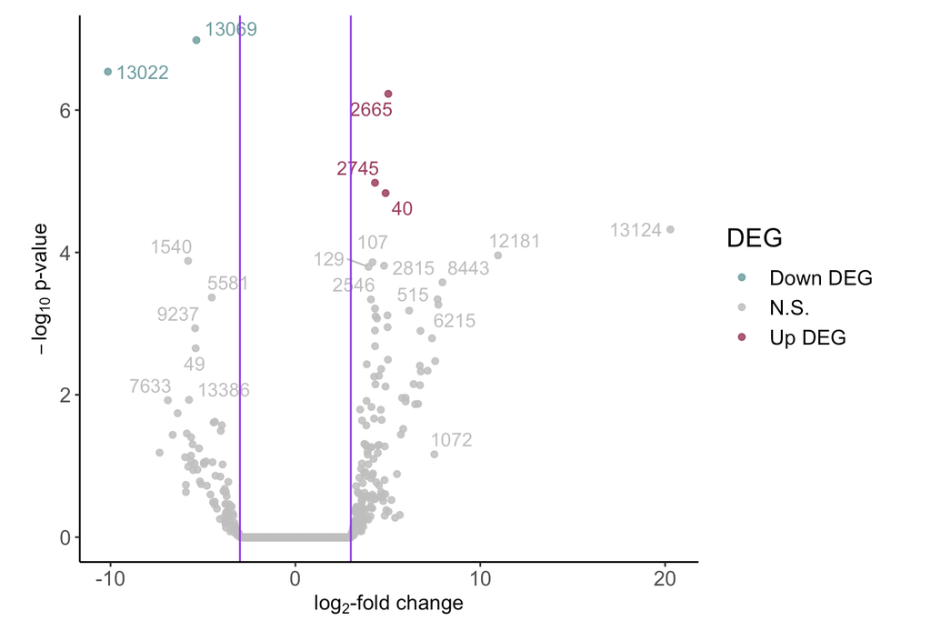

*Figure 2: Volcano plot of gene expression*

### Random Forest Model

To compare the differential expression analysis with DESeq2, we implemented a Random Forest model to classify the samples based on their treatment groups. The Random Forest algorithm was chosen for its robustness and ability to handle high-dimensional data, making it suitable for gene expression analysis. An out-of-box model was trained using a subset of the preprocessed gene expression data, and its performance was assessed to be 100%, albeit with the limited availability of data. We conducted a grid search to tune the model’s hyperparameters, including the number of variables tried at each split (mtry), the number of trees (ntree), and the split rule (gini or extratrees). The optimized model showed equal classification accuracy.